# MC_achilles

```r
library("ggpubr")
```

4 prism.achilles

4.1 Cleanup of prism.achilles

4.1.1 na removal

These three Rows had to be removed because Three rows of our prism.achilles dataframe contain NAs. These are the corresponding DepMap IDs

```r
# vector with NA rows - na.achilles
na.achilles <- c(277,309,323)
# Depmap ids of NA containing cellines
rownames(prism.achilles[na.achilles,])
```

```
## [1] "ACH-000836" "ACH-000901" "ACH-000939"
```

```r
# removing NA containing rows from achilles
prism.achilles <- prism.achilles[-na.achilles,]
```

We make Prism.achilles numeric

```r
prism.achilles.numeric <- apply(prism.achilles, 2, as.numeric)
# step below conserves rownames
rownames(prism.achilles.numeric) <- rownames(prism.achilles)
```

10.Intermission - Sort Prism.cl by depmap_id resulting in prism.cl.ordered

```r
# order prism.cl by DepMap_ID resulting in prism.cl.ordered
prism.cl.ordered <- prism.cl[order(prism.cl$DepMap_ID),]
# rownames are scrambled now -> reset
rownames(prism.cl.ordered) <- 1:nrow(prism.cl.ordered)
```

```r
# vector a with length of nrow prism.cl
a <- c(1:nrow(prism.cl.ordered))
# because prism cl is ordered we can easily remove the cellines, that have no achilles value, from prism.cl.ordered
# This loop checks if a certain celline has an achilles value and correspondingly writes a 0 or 1 into vector a
for(n in 1:481) {a[n] <- (prism.cl.ordered[n,1] %in% rownames(prism.achilles))}
# vector b contains the prism.cl rows / cellines that do not have an achilles value
b <- which(a == 0)
# remove prism.cl rows that don't have a corresponding achilles value
prism.cl.ordered.achilles <- prism.cl.ordered[-b, ]
# check dimensions of prism.cl.ordered.achilles
# reset rownames of prism.cl.ordered.achilles
rownames(prism.cl.ordered.achilles) <- 1:nrow(prism.cl.ordered.achilles)
```

Find PanCan Cellines in prism.cl.achilles

```r
# pancan.rownumbers is a vector with the row numbers that are pancreatic cancer cellines
pancan.rownumbers <- c(which(prism.cl.ordered.achilles[,20] == 'Pancreatic Cancer'))
# pancan.cl.names contains the DepMap IDs of the pancan cellines
pancan.cl.names <- prism.cl.ordered.achilles[pancan.rownumbers,1]
```

we Exploration of prism.achilles.numeric

```r
# More exploration

prism.achilles.numeric.pancan <- prism.achilles.numeric[pancan.rownumbers,]
```

We confirm that Our prism.achilles.numeric and prism.achilles.numeric.pancan dataframes are numeric and can be used for plotting histograms or calculating quantiles.

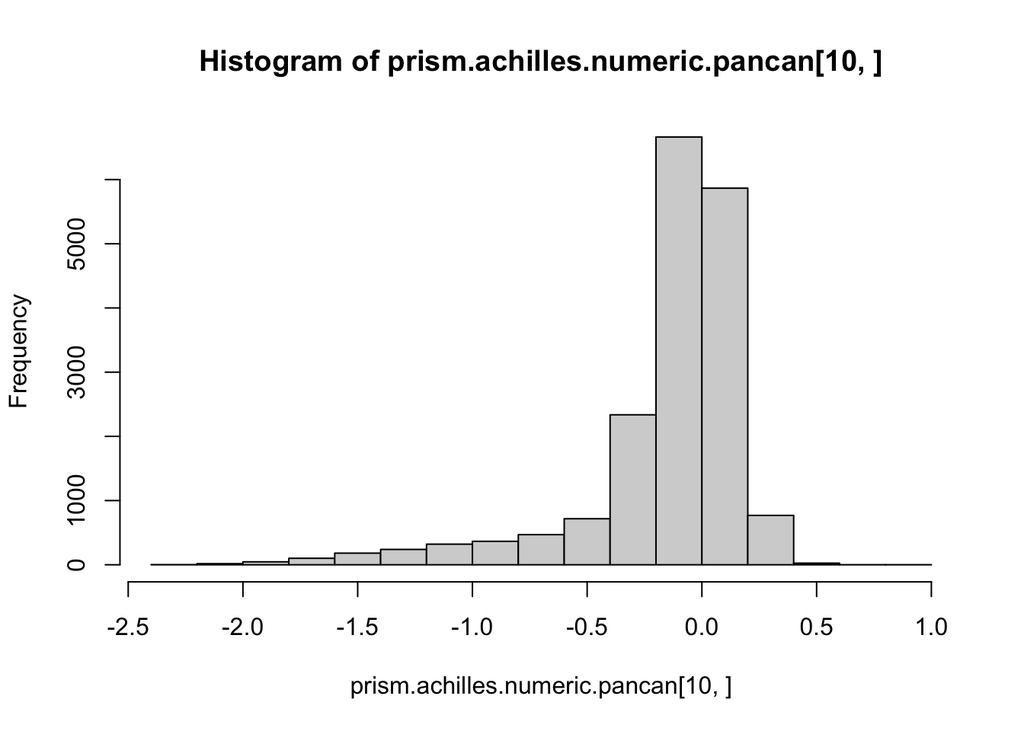

```r
# just confirming it is still numeric

hist(prism.achilles.numeric.pancan[10,])
```

```r
quantile(prism.achilles.numeric.pancan,probs=seq(0,1,.1))
```

```
##           0%          10%          20%          30%          40%          50%
## -3.013158370 -0.581997749 -0.287929545 -0.182443722 -0.113291797 -0.058112943
##          60%          70%          80%          90%         100%
## -0.007522533  0.042161024  0.097314728  0.169981701  2.390190374
```

```r
rownames(prism.achilles.numeric) <- rownames(prism.achilles)
```

New Dataframe for Analysis of prism.achilles.numeric

```r
# creates Dataframe with 10 rows and the same column count and names as prism.achilles
achilles.research.dataframe <- prism.achilles[1:10,]
# this sets all values of the research.dataframe to 0
achilles.research.dataframe[1:10,1:18119] <- 0
# this sets all rownames according to their future contents
rownames(achilles.research.dataframe) <- c('max','mean','min','10%quantile','Pancanmean','is(r5<r4)','stdev','empty8','empty9','empty10')

# fills first row of research.dataframe with the maximum value of the according prism.achilles.numeric column
achilles.research.dataframe[1,] <- apply(prism.achilles.numeric, 2, max)
# means of prism.achilles.numeric
achilles.research.dataframe[2,] <- apply(prism.achilles.numeric, 2, mean)
# min of prism.achilles.numeric
achilles.research.dataframe[3,] <- apply(prism.achilles.numeric, 2, min)
# 10% quantile of prism.achilles.numeric
achilles.research.dataframe[4,] <- apply(prism.achilles.numeric, 2, function(x){quantile(x,prob=0.1)})
# mean of prism.achilles.numeric.pancan
achilles.research.dataframe[5,] <- apply(prism.achilles.numeric.pancan, 2, mean)
# is 1 if mean of prism.achilles.numeric.pancan is smaller that 10% quantile of prism.achilles.numeric
achilles.research.dataframe[6,] <- apply(achilles.research.dataframe, 2, function(x) {return(x[4] > x[5])})
# var of prism.achilles.numeric
achilles.research.dataframe[7,] <- apply(prism.achilles.numeric, 2, var)
```

The four interesting genes

```r
achilles.research.dataframe[1:7,which(achilles.research.dataframe[6,] == 1)]
```

```
##                   DOCK5      KCNK13        KRAS         WLS
## max          0.43776386  0.53068373  0.06927002  0.41504652
## mean        -0.08222936 -0.03646742 -0.58201216  0.12194959
## min         -1.26474680 -2.36986289 -2.15523077 -0.80051723
## 10%quantile -0.35935966 -0.14240574 -1.28502818 -0.01467511
## Pancanmean  -0.41593873 -0.44466120 -1.30698799 -0.02380382
## is(r5<r4)    1.00000000  1.00000000  1.00000000  1.00000000
## stdev        0.05767614  0.09384127  0.17246569  0.01692432
```

Shapiro tests of the four interesting prism.achilles columns shows that their values are not normally distributed. Thus the comparison of the prism.achilles.numeric.pancan mean and prism.achilles.numeric 10% quantile are of no importance until further examination. Shown is the result of a Shapiro-Wilk normality test on column 4283 of our prism.achilles.numeric dataset.

```r
# these values show that the interesting columns are not completely normally distributed
shapiro.test(prism.achilles.numeric[,4283])
```

```
##
##  Shapiro-Wilk normality test
##
## data:  prism.achilles.numeric[, 4283]
## W = 0.88736, p-value = 2.696e-15
```

A qqplot between prism.achilles.numeric[,4283] and an according normal distribution results in the following graph. This shows that the values do not correspond to one single normal distribution.

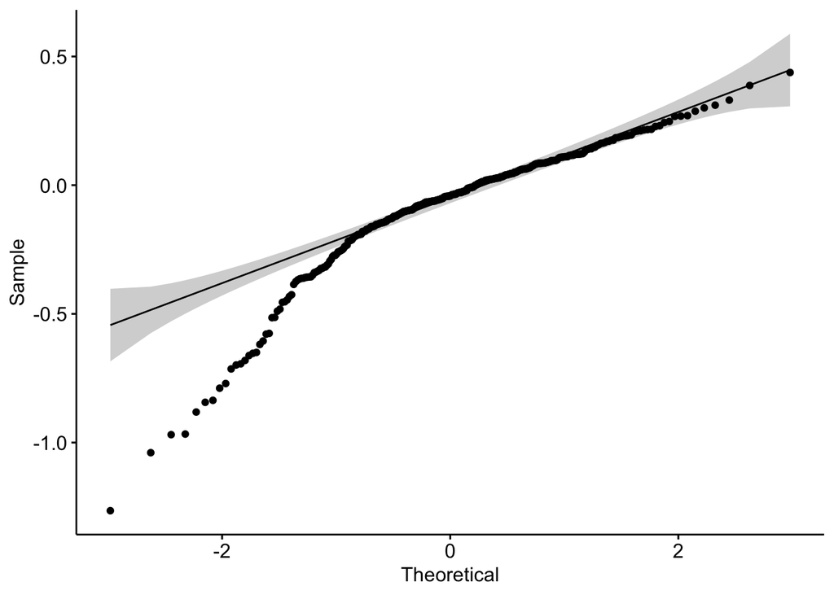

```r
ggqqplot(prism.achilles.numeric[,4283])
```

k-means clustering

Using the most variable, thus informative genes We first reduce our dataset to take the most variable gene, which are expected to carry most of the information about the samples:

```r
## compute variance over all rows of the data.frame (hence genes)
topVar = apply(prism.achilles.numeric, 2, var)
```

```r
## filtering to keep genes which have a variance greater than the 75% percentile
prism.achilles.numeric.topVar = prism.achilles.numeric[,topVar > quantile(topVar, probs = 0.75)]
```

Clustering by depmap

```r
mydata <- prism.achilles.numeric.topVar
# Determine number of clusters
wss.depmap <- (nrow(mydata)-1)*sum(apply(mydata,2,var))

for (i in 2:10) wss.depmap[i] <- sum(kmeans(mydata, centers=i)$withinss)
```

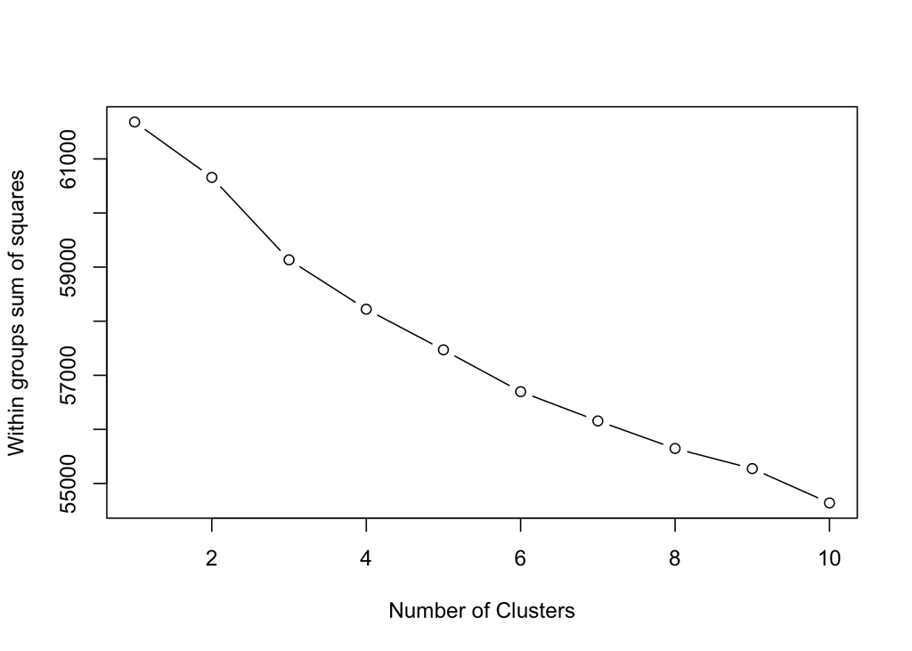

```r
plot(1:10, wss.depmap[1:10], type="b", xlab="Number of Clusters",
  ylab="Within groups sum of squares")
```

```r
km.depmap = kmeans(x=prism.achilles.numeric.topVar,
            centers = 2,
            nstart = 10)
km.depmap$cluster[1:10]
```

```
## ACH-000007 ACH-000011 ACH-000012 ACH-000013 ACH-000014 ACH-000015 ACH-000018
##          1          2          1          1          2          1          2
## ACH-000019 ACH-000021 ACH-000022
##          1          1          1
```

```r
summary(km.depmap)
```

```
##              Length Class  Mode
## cluster       347   -none- numeric
## centers      9060   -none- numeric
## totss           1   -none- numeric
## withinss        2   -none- numeric
## tot.withinss    1   -none- numeric
## betweenss       1   -none- numeric
## size            2   -none- numeric
## iter            1   -none- numeric
## ifault          1   -none- numeric
```

```r
km.depmap$cluster[pancan.cl.names]
```

```
## ACH-000022 ACH-000042 ACH-000060 ACH-000108 ACH-000118 ACH-000138 ACH-000164
##          1          2          2          2          1          1          2
## ACH-000178 ACH-000222 ACH-000235 ACH-000243 ACH-000265 ACH-000266 ACH-000281
##          2          2          2          2          1          2          2
## ACH-000307 ACH-000320 ACH-000332 ACH-000468 ACH-000502 ACH-000517 ACH-000535
##          1          1          2          2          2          2          1
## ACH-000599 ACH-000601 ACH-000652 ACH-000685
##          2          2          1          1
```